# Existe uma Área mais fácil na Segunda Fase do Exame da OAB? Um exemplo de viés de seleção

Guilherme Jardim Duarte

15-01-2015

Ontem li um texto interessante no Conjur, de Alvaro de Azevedo Gonzaga, intitulado [“Estudo da FGV mostra quem passa no exame da Ordem”](http://www.conjur.com.br/2015-jan-14/alvaro-gonzaga-estudo-fgv-mostra-quem-passa-exame-ordem?utm_source=dlvr.it&utm_medium=twitter). O texto apresenta alguns dados retirados de um [relatório](http://fgvprojetos.fgv.br/sites/fgvprojetos.fgv.br/files/relatorio_2_edicao_final.pdf) da FGV Projetos, em parceria com o Conselho Federal da OAB. O [Relatório “Exame da Ordem em Numeros”]((http://fgvprojetos.fgv.br/sites/fgvprojetos.fgv.br/files/relatorio_2_edicao_final.pdf) fornece estatística descritiva sobre examinandos e Instituições Superiores às quais estão vinculados.

O Relatório apresenta uma série de estatísticas interessantes (e provavelmente escreverei) mais sobre eles (não descobri se divulgam o banco de dados, por enquanto me contento em discutir os resumos), mas um tema em específico me interessou. Há uma tabela comparando a aproveitamento médio na prova discursiva do II ao XIII Exame Unificado:

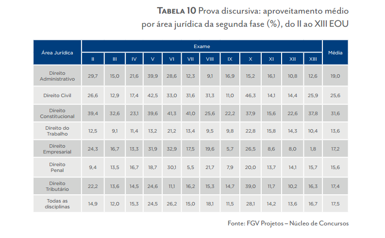

Para quem não conhece o Exame da Ordem, ele é realizado em duas fases: uma primeira prova objetiva com conteúdo abrangente de várias áreas do Direito e uma segunda, composta por uma peça profissional e quatro questões práticas, de uma área específica escolhida pelo candidato. Para essa segunda fase, há 7 áreas a serem escolhidas hoje: Direito Administrativo, Direito Civil, Direito Constitucional, Direito Empresarial, Direito Penal, Direito do Trabalho ou Direito Tributário.

Alvaro Gonzaga, no texto do Conjur, trouxe uma discussão oportuna:

> Ouço alguns folclores nos corredores de faculdades e cursinhos que basicamente profetizam o seguinte:

> “A melhor área para se prestar na segunda fase é Penal ou Trabalho, isso porque são matérias do dia a dia, vemos situações de violência reportadas cotidianamente, bem como estabelecemos relações laborais constantemente. Isso gera uma falsa aderência natural para o candidato que escolhe essas matérias.”

> Dos folclores negativos, embora também envolvam relações cotidianas, temos o Direito Civil como líder. Quando alguém diz que irá prestar Civil na segunda fase:

> “Você é louco? Civil? Você tem ideia de quantas peças existem em civil?”

Lembro que, quando prestei, ouvia histórias semelhantes: “Cuidado com Penal. Todos prestam essa disciplina e a instituição está dificultando a prova para que ninguém passe.”

A questão é: é possível com a tabela identificar uma área mais difícil que a outra? Uma resposta ingênua seria comparar os aproveitamentos médios nas áreas e verificar qual deles é maior. É uma resposta ingênua, porque é provável que isso nos trará conclusões incorretas por um problema de [VIÉS DE SELEÇÃO](http://en.wikipedia.org/wiki/Selection_bias), que explicarei. Primeiro, vou plotar um gráfico das séries históricas dadas nas tabelas para enxergarmos melhor os dados.

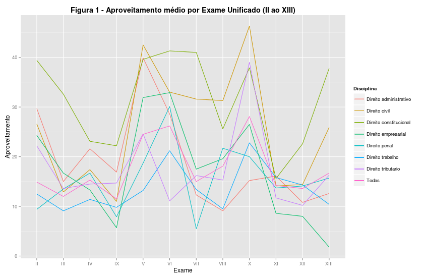

Dá para verificar olhando a tabela e o gráfico que quem presta Civil, Administrativo e Constitucional apresenta em média um aproveitamento melhor que as outras áreas. Isso quer dizer que é mais vantajoso prestar uma dessas áreas? O viés de seleção aparece porque quem escolhe essas disciplinas é diferente daqueles que escolhem outros, mesmo em média.

O que todos se perguntam é se escolher uma área é mais vantajoso que escolher outra. É possível que a prova de Constitucional seja mais fácil que as de outras áreas, mantendo um nível de dificuldade e outras variáveis constantes (por ter menos peças a se estudar, por exemplo)? Talvez possamos responder essa questão, mas para isso deveríamos delinear uma estratégia de pesquisa capaz de detectar essa causalidade (“estratégia de identificação”). Falaremos sobre isso em outro post.